```python
import numpy as np
import pandas as pd
import statsmodels
import statsmodels.api as sm
from statsmodels.tsa.stattools import coint, adfuller
import statsmodels.tsa.stattools as ts

import matplotlib.pyplot as plt
import seaborn as sns
```

# **Int on premice of financial analysis, quant trading course exemple**

En premier lieu on va générer une serie de prix test pour expliquer les concepts suivant :

- Bruit blanc gaussien (temps discret) et son extension le Mvt brownien (temps continue)
- Stationnarité d'un série temporelle

```python
def generate_data(params):
    mu = params[0]
    sigma = params[1]
    return np.random.normal(mu, sigma)
```

Cette fonction prend en entrée un tuple (μ,σ) et retourne un échantillon unique tiré d'une distribution Normale (Gaussienne).

𝑋∼𝑁(𝜇,𝜎^2).

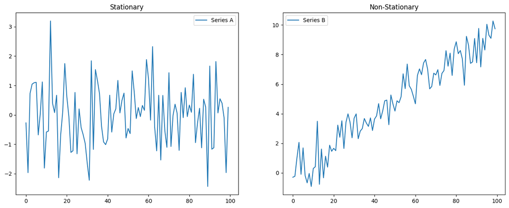

```python
params = (0, 1)
T = 100

A = pd.Series(index=range(T))
A.name = 'A'

for t in range(T):
    A[t] = generate_data(params)

T = 100

B = pd.Series(index=range(T))
B.name = 'B'

for t in range(T):
    params = (t * 0.1, 1)
    B[t] = generate_data(params)

fig, (ax1, ax2) = plt.subplots(nrows =1, ncols =2, figsize=(16,6))

ax1.plot(A)
ax2.plot(B)
ax1.legend(['Series A'])
ax2.legend(['Series B'])
ax1.set_title('Stationary')
ax2.set_title('Non-Stationary')
```

**Seria A stationnaire :**

Nous fixons μ=0 et σ=1. Nous générons 100 points de données (T=100) en utilisant ces paramètres, de sorte que chaque A_t est tiré de la même distribution :

𝐴_𝑡∼N(0,1),pour t=1,2,…,T. Comme μ et 𝜎 restent constants dans le temps, la distribution de A_t ne dépend pas de t.

Cela implique que la série est stationnaire, dans le sens où ses propriétés statistiques (moyenne, variance) ne changent pas avec le temps.

**Meme question sur B :**

**Answer :** Ici, nous permettons à la moyenne de changer à chaque instant t. Plus précisément, pour chaque t :

𝜇_𝑡=0.1×𝑡 ,𝜎_𝑡=1.

Ainsi, chaque 𝐵_𝑡 est tiré de la distribution suivante :

𝐵_𝑡 ∼N(0.1t,1).

À mesure que t augmente, la moyenne de la distribution augmente progressivement. Cela rend la série non stationnaire, car sa valeur attendue dépend du temps t.

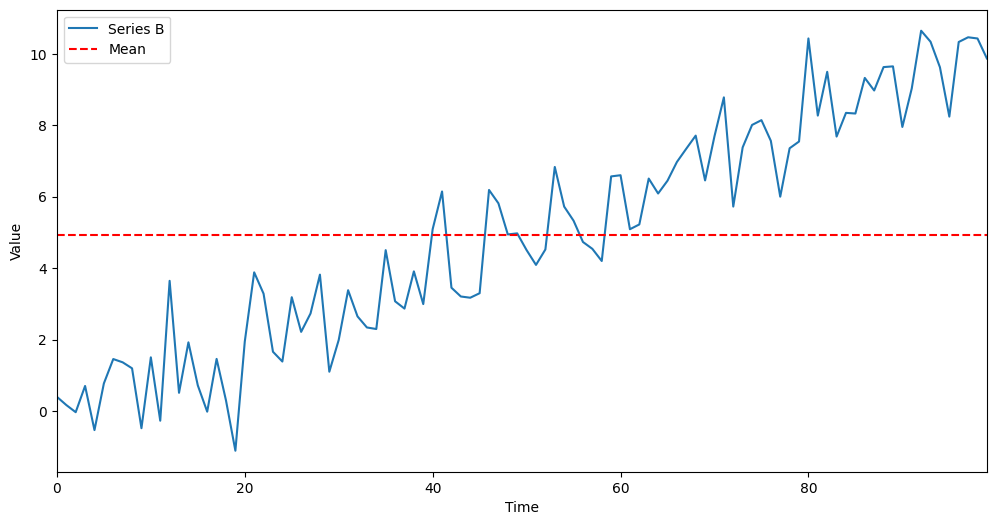

```python
mean = np.mean(B)

plt.figure(figsize=(12,6))
plt.plot(B)
plt.hlines(mean, 0, len(B), linestyles='dashed', colors = 'r')
plt.xlabel('Time')
plt.xlim([0, 99])
plt.ylabel('Value')
plt.legend(['Series B', 'Mean'])
```

La moyenne calculée représentera bien la moyenne de tous les points de données, mais elle ne sera d'aucune utilité pour prévoir un état futur. Elle n'a aucune signification lorsqu'on la compare à un instant précis, car elle regroupe des états différents à différents moments sans tenir compte de l’évolution temporelle.

Ceci est un exemple simple et clair de comment la non-stationnarité peut fausser l'analyse, mais en pratique, des problèmes beaucoup plus subtils peuvent apparaître.

Test de stationnarité :

```python
def stationarity_test(X, cutoff=0.05):
    # H_0 in adfuller is unit root exists (non-stationary)
    # We must observe significant p-value to convince ourselves that the series is stationary
    pvalue = adfuller(X)[1]
    if pvalue < cutoff:
        print('p-value = ' + str(pvalue) + ' The series ' + X.name +' is likely stationary.')
    else:
        print('p-value = ' + str(pvalue) + ' The series ' + X.name +' is likely non-stationary.')

stationarity_test(A)
stationarity_test(B)
```

[output not shown]

```python
print(adfuller(B,regression='ct'))
print('B is stationary with trend')
```

```
(np.float64(-6.6417510960938895), np.float64(8.977627717986368e-08), 3, 96, {'1%': np.float64(-4.056309393220125), '5%': np.float64(-3.4572550874385124), '10%': np.float64(-3.1544345187717013)}, np.float64(239.22238011156978))
B is stationary with trend
```

## **Conclusion :**

**Pourquoi la stationnarité est-elle importante ?**

Une série temporelle stationnaire possède des propriétés statistiques constantes dans le temps (c’est-à-dire que la moyenne, la variance et la structure d’autocorrélation ne changent pas).

Une série temporelle non stationnaire, en revanche, a au moins une de ces propriétés qui évolue avec le temps (souvent la moyenne). Dans le cadre de la modélisation financière, de nombreuses séries de prix montrent des tendances ou une volatilité variable, ce qui les rend non stationnaires.

➡️ Pourquoi c’est important en finance quantitative ? Identifier la stationnarité est essentiel car de nombreux modèles statistiques et de prévision (comme les modèles ARIMA, les tests de cointégration, etc.) supposent ou nécessitent que la série étudiée soit stationnaire.

- Avant d’appliquer un modèle, on teste la stationnarité (ex : test ADF - Augmented Dickey-Fuller)
- Si la série n’est pas stationnaire, on peut la transformer (ex : différenciation, log-transformation, filtrage) pour qu’elle le devienne.

**La stationnarité est cruciale pour la cointégration** **📌 Problème :**

La cointégration est une propriété qui permet d’identifier des relations de long terme entre plusieurs séries financières (ex : deux actifs fortement liés). Si deux séries sont cointegrées, cela signifie qu’il existe une relation stable entre elles et que leur écart (spread) est stationnaire.

**📌 Exemple :**

Supposons qu’on observe les prix de Binance et Deribit pour un même contrat futur. Individuellement, ces prix peuvent être non stationnaires (car ils suivent des tendances du marché). Mais si leur spread est stationnaire, cela signifie qu’ils évoluent de manière cohérente à long terme. Ce type d’analyse permet d’identifier des opportunités d’arbitrage et de pairs trading.

**✅ Solution :**

On teste la cointégration en vérifiant si une combinaison linéaire des deux séries est stationnaire (ex : test d’Engle-Granger). Si le spread est stationnaire, cela signifie qu’il y a une relation structurelle forte entre les actifs → signal exploitable en trading.

# **I/ Choix et analyse d'un instrument : Future a maturité**

Ici on fetch les data avec la librairy ccxt des données historique en 15 mins.

```python
def fetch_symbol_closes_df(symbol_str):
    import ccxt, pandas as pd
    from functools import reduce

    symbol = symbol_str
    timeframe = '15m'
    start_date = '2025-01-01T00:00:00Z'
    exchanges = ['binance', 'deribit']
    frames = []

    for ex_id in exchanges:
        ex = getattr(ccxt, ex_id)()
        ex.load_markets()

        since = ex.parse8601(start_date)
        limit = 500
        all_ohlcv = []

        while True:
            ohlcv = ex.fetch_ohlcv(symbol, timeframe, since, limit)
            if not ohlcv:
                break
            all_ohlcv += ohlcv

            since = ohlcv[-1][0] + 1
            if len(ohlcv) < limit:
                break

        df = pd.DataFrame(all_ohlcv, columns=['ts','o','h','l','c','v'])
        df['datetime'] = pd.to_datetime(df['ts'], unit='ms')
        df = df[['datetime','c']].rename(columns={'c': ex_id})
        frames.append(df)

    final_df = reduce(lambda left, right: pd.merge(left, right, on='datetime', how='outer'), frames)
    final_df.sort_values('datetime', inplace=True)
    final_df.reset_index(drop=True, inplace=True)
    return final_df
```

```python
def plot_btc_closes(df):
    plt.figure()
    plt.plot(df['datetime'], df['binance'], label='Binance')
    plt.plot(df['datetime'], df['deribit'], label='Deribit')
    plt.legend()
    plt.show()
```

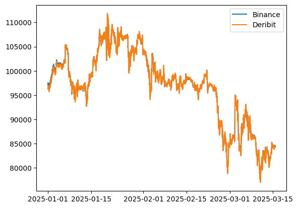

```python
df = fetch_btc_closes_df('BTC/USD:BTC-250328')
plot_btc_closes(df)
```

# **Calcul du spread et méthode pour smooth le spread**

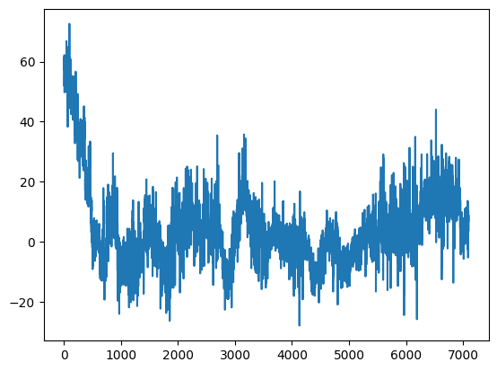

```python
df['spread'] = ((df['binance']-df['deribit'])/df['deribit'])*10000
window = 10
df['spread_smooth'] = df['spread'].rolling(window, center=True).mean()
df['spread_smooth'] = df['spread'].ewm(span=window).mean()

plt.plot(df['spread'])
```

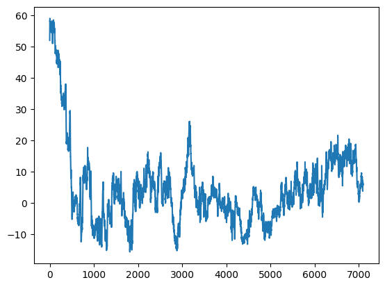

```python
plt.plot(df['spread_smooth'])
```

**Interressant de faire attention a la façon dont ont smooth les data**

- Average sur une fenetrte de temps
- EMA qui met en avant l'importance des derniere valeur
- Plus de méthode avec de l'interpolation

```python
spread_series = df['spread_smooth']
adf_result = ts.adfuller(spread_series, autolag='AIC')
p_value = adf_result[1]

if p_value < 0.05:
    print("Spread stationnaire => cointégration plausible.")
else:
    print("Spread non stationnaire => pas de cointégration (ou pas évident).")
```

```
Spread stationnaire => cointégration plausible.
```

```python
def estimate_coint_and_adf(df):

    df = df.dropna(subset=['binance', 'deribit']).copy()

    # 2. Y = binance, X = deribit + intercept
    Y = df['binance']
    X = sm.add_constant(df['deribit'])  # Ajoute l'intercept

    # 3. Régression OLS => Y = alpha + beta * X
    model = sm.OLS(Y, X).fit()

    alpha = model.params['const']
    beta  = model.params['deribit']

    # 4. Résidu (epsilon)
    df['epsilon'] = Y - alpha - beta * df['deribit']

    # 5. Test ADF sur epsilon
    adf_result = ts.adfuller(df['epsilon'], autolag='AIC')
    p_value = adf_result[1]

    return alpha, beta, df['epsilon'], p_value, model

alpha, beta, eps, p_value, model = estimate_coint_and_adf(df)

print("alpha =", alpha)
print("beta  =", beta)
print("p-value du test ADF sur epsilon =", p_value)
if p_value < 0.05:
    print("=> epsilon stationnaire => cointégration plausible.")
else:
    print("=> pas de stationnarité => pas de cointégration (ou pas évidente).")
```

```
alpha = 270.7168288430945
beta  = 0.9976384857776036
p-value du test ADF sur epsilon = 0.00017265077866506404
=> epsilon stationnaire => cointégration plausible.
```

Cette fonction applique la méthode d’Engle-Granger pour tester la cointégration : Nettoyage des NaN (lignes incomplètes). Définition de Binance=𝛼+𝛽×Deribit.

Régression linéaire OLS pour obtenir 𝛼 et 𝛽.

ε=Binance−α−β×Deribit. Test ADF sur ce résidu pour juger sa stationnarité. Si ε est stationnaire, on conclut à une cointégration des deux prix.

# **Génération d'un signal basé sur le z-score**

**Z-Score :**

zscore = (spread_smooth − mean_spread) / std_spread

Le Z-Score indique de combien d’écarts-types le spread courant s’éloigne de sa moyenne.

- Un Z-Score proche de 0 signifie que le spread est “normal” (autour de sa moyenne).
- Un Z-Score élevé (supérieur à +2, par exemple) signifie que le spread est “trop haut” par rapport à sa moyenne historique.
- Un Z-Score bas (inférieur à –2) signifie que le spread est “trop bas”.

```python
window = 500

df['mean_spread'] = df['spread_smooth'].rolling(window).mean()
df['std_spread']  = df['spread_smooth'].rolling(window).std()

# Calcule le Z-score du spread
df['zscore'] = (df['spread_smooth'] - df['mean_spread']) / df['std_spread']

# Exemple simple de stratégie
# Si zscore > +2 => spread "trop haut" => short le spread (short binance, long deribit)
# Si zscore < -2 => spread "trop bas"  => long le spread  (long binance, short deribit)

df['signal'] = 0
df.loc[df['zscore'] >  2, 'signal'] = -1  # short spread
df.loc[df['zscore'] < -2, 'signal'] =  1  # long spread

# Optionnel: fermer la position si le zscore repasse autour de 0
df.loc[df['zscore'].abs() < 0.5, 'signal'] = 0
```

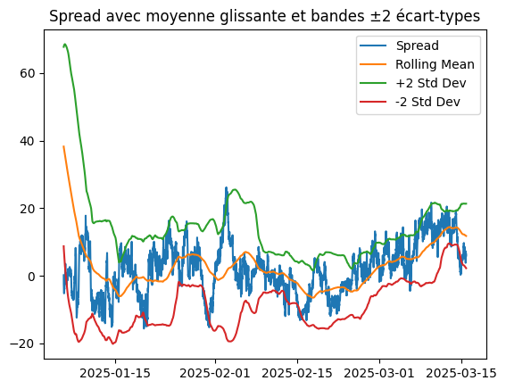

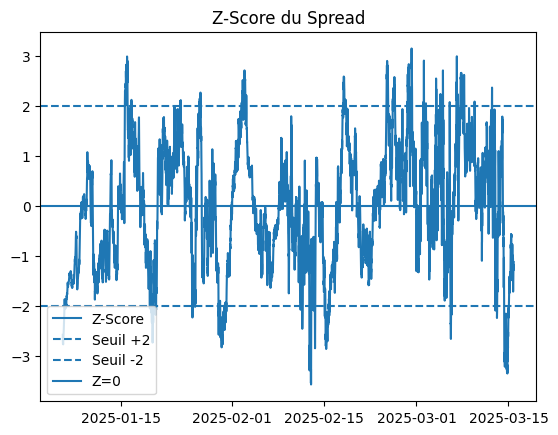

```python
def plot_spread_and_signals(df):
    df = df.dropna(subset=['datetime', 'spread_smooth', 'mean_spread', 'std_spread', 'zscore']).copy()

    # 1) Graphique du spread avec la mean et ±2 std
    plt.figure()
    plt.plot(df['datetime'], df['spread_smooth'], label='Spread')
    plt.plot(df['datetime'], df['mean_spread'], label='Rolling Mean')
    plt.plot(df['datetime'], df['mean_spread'] + 2 * df['std_spread'], label='+2 Std Dev')
    plt.plot(df['datetime'], df['mean_spread'] - 2 * df['std_spread'], label='-2 Std Dev')
    plt.legend()
    plt.title("Spread avec moyenne glissante et bandes ±2 écart-types")
    plt.show()

    # 2) Graphique du Z-Score
    plt.figure()
    plt.plot(df['datetime'], df['zscore'], label='Z-Score')
    plt.axhline(y= 2, linestyle='--', label='Seuil +2')
    plt.axhline(y=-2, linestyle='--', label='Seuil -2')
    plt.axhline(y= 0, linestyle='-', label='Z=0')
    plt.legend()
    plt.title("Z-Score du Spread")
    plt.show()

plot_spread_and_signals(df)
```

**Signaux de trading :**

- Quand le Z-Score dépasse +2, on considère le spread surévalué → on prend une position short sur le spread.

(Dans le cas d’un spread = prix Binance – prix Deribit, être short sur le spread reviendrait à vendre Binance et acheter Deribit.)

- Quand le Z-Score passe en dessous de –2, on considère le spread sous-évalué → on prend une position long sur le spread.

(Acheter Binance et vendre Deribit, par exemple.)

- Pour éviter de garder des positions ouvertes quand le signal redevient neutre, on fixe une zone de “sortie” ou de “non-position” lorsque le Z-Score se rapproche de 0 (par exemple si abs(zscore) < 0.5).

# **Backtest**

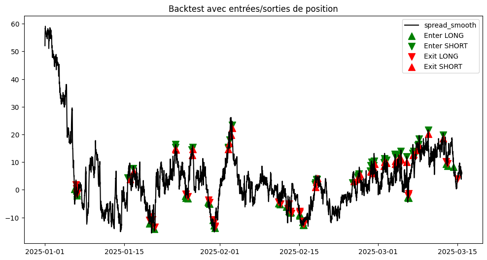

```python
def plot_trades(df, price_col='spread', signal_col='signal'):

    # On va stocker les points (x,y) pour chaque événement
    enter_long_x, enter_long_y = [], []
    enter_short_x, enter_short_y = [], []
    exit_long_x, exit_long_y = [], []
    exit_short_x, exit_short_y = [], []

    # Pour parcourir les changements de signal
    df = df.copy().reset_index(drop=True)

    # Signal initial
    prev_sig = df.loc[df.index[0], signal_col]

    # Boucle sur chaque rangée à partir de la 2ème
    for i in range(1, len(df)):
        cur_sig = df.loc[i, signal_col]

        if cur_sig != prev_sig:
            # => Le signal vient de changer
            if cur_sig == 1:
                # Changement vers un long
                enter_long_x.append(df.loc[i, 'datetime'])
                enter_long_y.append(df.loc[i, price_col])
            elif cur_sig == -1:
                # Changement vers un short
                enter_short_x.append(df.loc[i, 'datetime'])
                enter_short_y.append(df.loc[i, price_col])
            else:
                # cur_sig == 0 => On sort d'une position
                if prev_sig == 1:
                    # On sort d'un long
                    exit_long_x.append(df.loc[i, 'datetime'])
                    exit_long_y.append(df.loc[i, price_col])
                elif prev_sig == -1:
                    # On sort d'un short
                    exit_short_x.append(df.loc[i, 'datetime'])
                    exit_short_y.append(df.loc[i, price_col])

        prev_sig = cur_sig

    # --- Tracé du graphique ---
    plt.figure(figsize=(12, 6))
    plt.plot(df['datetime'], df[price_col], label=price_col, color='black')

    # Entrées en position
    plt.scatter(enter_long_x, enter_long_y, marker='^', color='green', s=100, label='Enter LONG')
    plt.scatter(enter_short_x, enter_short_y, marker='v', color='green', s=100, label='Enter SHORT')
    # Sorties de position
    plt.scatter(exit_long_x, exit_long_y, marker='v', color='red', s=100, label='Exit LONG')
    plt.scatter(exit_short_x, exit_short_y, marker='^', color='red', s=100, label='Exit SHORT')

    plt.title("Backtest avec entrées/sorties de position")
    plt.legend()
    plt.show()

plot_trades(df, price_col='spread_smooth', signal_col='signal')
```